# DA3_HW2_Summary-Report

Gyebnar Daniel

2022 02 09

# Assessment of rbnb aparment prices in Rome

## Goal and data used

CityRent, a company specialized in operating rbnb apartments in major European cities, aims to enter the market in Rome.

The goal of this paper is to summaries the key findings regarding the pricing mechanism of small and mid sized rbrb apartments in Rome. The paper will give insights on the market, how to best price the apartments given its key attributes, and what the best practices are for operating these apartments.

The study was conducted using data from http://insideairbnb.com/get-the-data.html. The models were built on a data set containing 16.273 observations and 416 variables.

## Market overview

| neighbourhood_cleansed |  | N | Percent | Mean | Median | SD |
| --- | --- | --- | --- | --- | --- | --- |
| I Centro Storico | price | 8778 | 54.12 | 98.80 | 86.00 | 52.61 |
| II Parioli/Nomentano | price | 1130 | 6.97 | 76.20 | 65.00 | 46.68 |
| III Monte Sacro | price | 250 | 1.54 | 60.35 | 53.50 | 32.76 |
| IV Tiburtina | price | 302 | 1.86 | 58.72 | 50.00 | 42.61 |
| IX Eur | price | 188 | 1.16 | 70.51 | 63.00 | 39.40 |
| V Prenestino/Centocelle | price | 670 | 4.13 | 50.72 | 46.00 | 24.70 |
| VI Roma delle Torri | price | 116 | 0.72 | 57.02 | 49.00 | 35.82 |
| VII San Giovanni/CinecittÄ‚Â | price | 1193 | 7.36 | 66.51 | 60.00 | 35.74 |
| VIII Appia Antica | price | 493 | 3.04 | 68.13 | 60.00 | 39.00 |
| X Ostia/Acilia | price | 405 | 2.50 | 76.46 | 61.00 | 46.11 |
| XI Arvalia/Portuense | price | 294 | 1.81 | 62.74 | 59.00 | 29.83 |
| XII Monte Verde | price | 848 | 5.23 | 73.03 | 66.00 | 37.24 |
| XIII Aurelia | price | 975 | 6.01 | 76.74 | 69.00 | 39.86 |
| XIV Monte Mario | price | 339 | 2.09 | 69.61 | 60.00 | 41.93 |
| XV Cassia/Flaminia | price | 238 | 1.47 | 73.83 | 60.00 | 43.66 |

## Key decision points

#### Observation selection

I excluded apartments above 400 EUR per night. This cutoff still leaves plenty of extreme values as the 3rd quartile is 100 EUR. I dropped observations where price was missing (see histogram of prices below)

#### Variable selection

I selected 40 variables from the original data set (apart from amenities). I excluded variables that were redundant, had very little variation, or variables with irrelevant underlying meaning based on my domain knowledge.

#### Dealing with NAs

Variables regarding the reviews had many, c.20% missing values. I flagged these missing values and imputed 0 in order to keep the variables numeric. Variables regarding the host (eg. host since, superhost, ect.) had only a few missing values (<5%) so I decided to impute them with the median. For the few missing integer values, I imputed a replacement value from another variable based on domain knowledge (e.g. missing number of beds equal to number of accommodates, missing number of bedrooms equal to accommodates divided by 2)

#### Feature engineering

I clustered variables into factors, dummies and numeric. For a categorical variable with many values I created a factor, e.g. Neighborhood, for categorical with 2 values I created a dummy with 0 or 1, and for numeric integers I decided individually whether to keep as numeric or to transform to factors (e.g. accommodates). I also created two additional variables, bathroom-bedroom ratio, and host years of experience.

#### Amenities

I extracted all 379 amenities from the raw data, organized it into a dataframe, ordered it according to frequency, and included it into the model as separate dummy variables (e.g. is there a TV)

## Key findings and reccomendations

#### Market insights

The histogram of price per night suggest that the typical apartment costs EUR 74 per night, and the average is EUR 85.

[figure not shown]

Histogram of prices per night

#### Key attributes to consider

The variables that are the most important are reviews regarding the location, the total listings of hosts (suggesting that professionals with more listings have higher prices), number of accommodates, and the ratio of bathrooms to guests (based on variable importance plots from annex).

## Modeling process

- property: contains variables that describe the location and the type of real estate, e.g. neighborhood, property type
- size: contains variables that describe the size of the real estate and its layout, e.g.: beds, bathrooms, number of accommodations, bathroom-guest ratio
- host: contains variables that describe the details about the host, e.g. is the host a local, how many years of experience the host has
- booking: contains variables that describe the booking options, e.g. minimum nights, response time
- reviews: contains variables on the reviews, e.g. overall rating, number of reviews, and the flags of missing values
- amenities: contains items and extras that are available, e.g. TV, AC, ect. I created 3 variations to this group, to be used as model complexity increases: one with 10 and one with 50 most frequent amenity, and one with all 379 amenities (amenities 2, 3, and 4)
- interactions: I created interactions, mostly for the number of guests, reviews, and neighborhood, and their combination

I have created the following formulas, with model 1 being the simplest, and model 4 being a reasonably complex model with top 50 amenities, and model 5 with all 379 amenities:

- model 1: simplest model with n_accommodates as the only variable
- model 2: price ~ size, property
- model 3: price ~ size, property, reviews, amenities_2
- model 4: price ~ size, property, reviews, host, booking, amenities_3, interactions
- model 5: price ~ size, property, reviews, host, booking, amenities_4, interactions

From model 1-5 I created OLS models with 5-fold cross validation, and selected model 4 for Random Forest and GBM. I used the most complex model, model 5, for LASSO.

After training, I evaluated the OLS, the LASSO, the Random Forest, and the GBM model on the holdout set.

I used the coefficients of the OLS model to explain the key insights on the market in general, and I used the partial dependence plot of the GBM and the variable importance plot from the Random Forest to draw my conclusions.

## Interpretation of model results

OLS and LASSO detailed results

| Model | Coefficients | R_squared | BIC | Training_RMSE | Test_RMSE |
| --- | --- | --- | --- | --- | --- |
| OLS M1 | 2 | 0.1259401 | 138642.4 | 49.64776 | 49.63445 |
| OLS M2 | 31 | 0.2627405 | 136701.2 | 45.59731 | 45.70278 |
| OLS M3 | 57 | 0.3237695 | 135822.7 | 43.66932 | 43.91519 |
| OLS M4 | 129 | 0.3561310 | 135866.4 | 42.61160 | 43.06855 |
| OLS M5 | 380 | 0.3812255 | 137726.8 | 41.77296 | 43.14609 |
| LASSO M5 | 212 | 0.3436237 | NA | NA | 43.02903 |

The graph below shows how test RMSE decreases until Model 4, while increases for Model 5

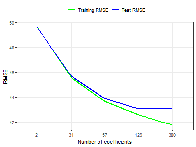

Test & Train RMSE by coefficients for OLS models

My conclusion is that the well constructed Model 4 performed only slightly below the LASSO model. I selected to use Model 4 for another roudn of calculations with Random Forest and GBM

RMSE on the holdout set

| Model | CV.RMSE | Holdout.RMSE |
| --- | --- | --- |
| OLS M4 | 43.11349 | 42.63775 |
| LASSO M5 | 43.02903 | 42.42538 |
| RF M4 | 43.02483 | 42.59012 |
| GBM M4 | 42.34146 | 41.79039 |

The RMSE on the holdout sample is slightly below than the RMSE for the coros-validated test set. The lowest RMSE is for Model 4 with GBM method, followed by the LASSO on Model 5, and Random Forest and OLS on Model 4

## Annex

#### PDP Plots

[figure not shown]

PDP by property type

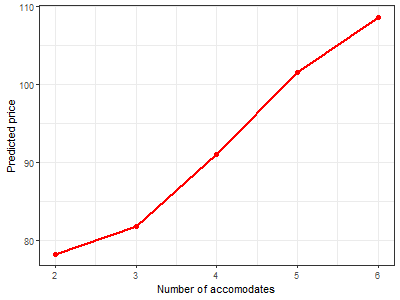

PDP by number of accomodates

[figure not shown]

PDP by neighborhood

#### Variable importance plots

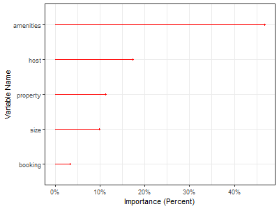

Variable importance by feature groups

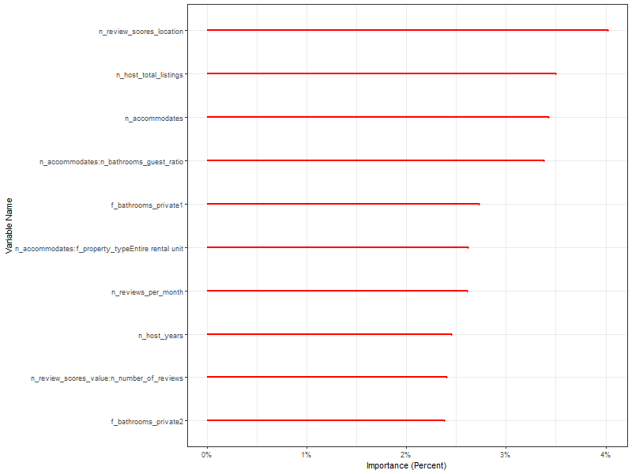

Variable importance of top 10 variables

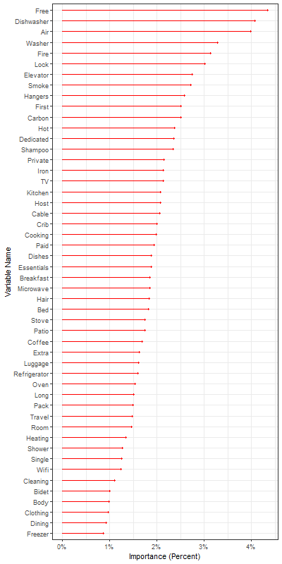

Variable importance of amenities